# Reproducible Research: Peer Assessment 1

### Loading and preprocessing the data

```r
activity <- read.csv("activity.csv")
```

### What is the mean total number of steps taken per day?

1. Calculate the total number of steps taken per day

```r
sumByDate <- setNames(aggregate(activity$step ~ activity$date, data = activity, FUN=sum, na.rm=TRUE), c("date","steps"))
```

2. Make a histogram of the total number of steps taken each day

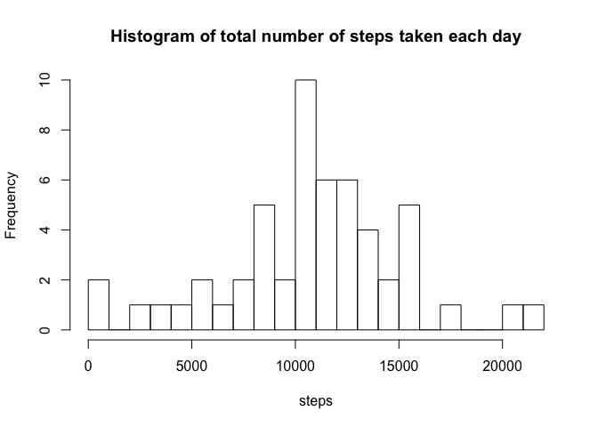

```r
hist(sumByDate$steps,breaks=20,main='Histogram of total number of steps taken each day',xlab='steps')
```

3. Calculate and report the mean and median of the total number of steps taken per day

Mean

```r
mean(sumByDate$steps)
```

```
## [1] 10766.19
```

Median

```r
median(sumByDate$steps)
```

```
## [1] 10765
```

### What is the average daily activity pattern?

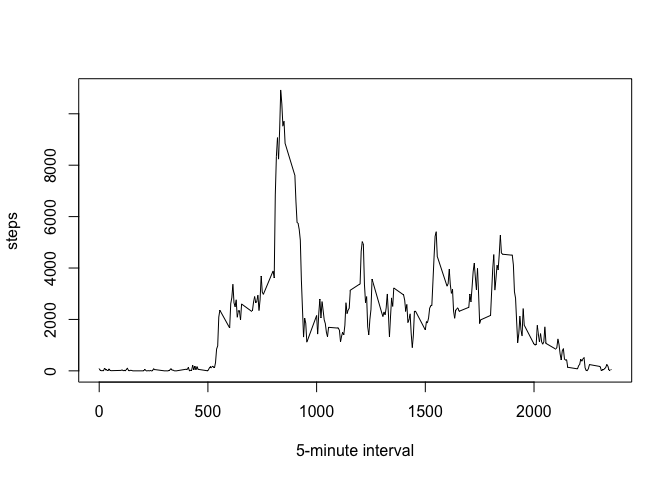

```r
meanByInterval <- setNames(aggregate(activity$steps ~ activity$interval, data = activity, FUN=sum, na.rm=TRUE), c("interval","steps"))
plot(meanByInterval$steps ~ meanByInterval$interval, data = meanByInterval,  type="l", ylab ="steps", xlab ="5-minute interval")
```

2. Which 5-minute interval, on average across all the days in the dataset, contains the maximum number of steps?

```r
meanByInterval[which.max(meanByInterval$steps), ]$interval
```

```
## [1] 835
```

### Imputing missing values

1. Calculate and report the total number of missing values in the dataset (i.e. the total number of rows with NAs)

```r
sum(is.na(activity$steps))
```

```
## [1] 2304
```

2. Devise a strategy for filling in all of the missing values in the dataset. The strategy does not need to be sophisticated. For example, you could use the mean/median for that day, or the mean for that 5-minute interval, etc.

Using mean for 5-minute intervals to replace NA values for step. E.g. the mean is derived for all days with intervals = 05. Days with intervals = 05 and steps = N.A. has the step value replaced with the derived means.

3. Create a new dataset that is equal to the original dataset but with the missing data filled in.

```r
activityNoNA <- activity
activityNoNA$steps[is.na(activityNoNA$steps)] <- with(activityNoNA, tapply(activityNoNA$steps, activityNoNA$interval, mean, na.rm=TRUE))
```

The total number of missing values in the dataset (i.e. the total number of rows with NAs) is now zero

```r
sum(is.na(activityNoNA$steps))
```

```
## [1] 0
```

4. Make a histogram of the total number of steps taken each day and Calculate and report the mean and median total number of steps taken per day. Do these values differ from the estimates from the first part of the assignment? What is the impact of imputing missing data on the estimates of the total daily number of steps?

1a. Calculate the total number of steps taken per day

```r
sumByDateAlt <- setNames(aggregate(activityNoNA$step ~ activityNoNA$date, data = activityNoNA, FUN=sum), c("date","steps"))
```

2a. Make a histogram of the total number of steps taken each day

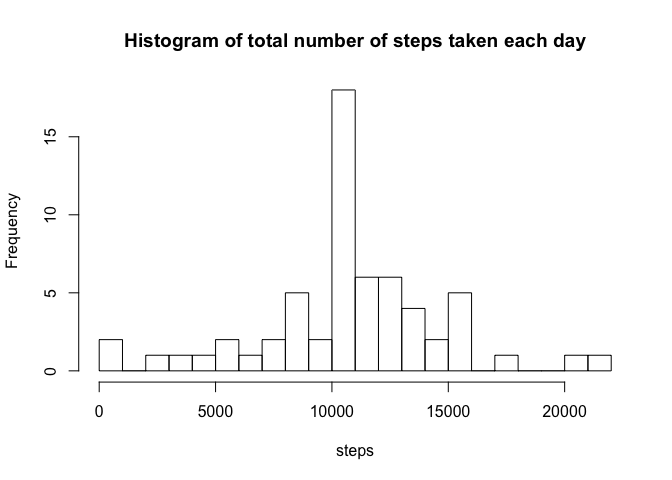

```r
hist(sumByDateAlt$steps,breaks=20,main='Histogram of total number of steps taken each day',xlab='steps')
```

3a. Calculate and report the mean and median of the total number of steps taken per day

Mean

```r
mean(sumByDateAlt$steps)
```

```
## [1] 10766.19
```

Median

```r
median(sumByDateAlt$steps)
```

```
## [1] 10766.19
```

### Are there differences in activity patterns between weekdays and weekends?

1. Create a new factor variable in the dataset with two levels – “weekday” and “weekend” indicating whether a given date is a weekday or weekend day.

```r
activityDate <- activityNoNA
activityDate$date <- as.Date(activityDate$date)
weekdays <- c('Monday', 'Tuesday', 'Wednesday', 'Thursday', 'Friday')
activityDate$category <-  factor((weekdays(activityDate$date) %in% weekdays)+1L,
      levels=1:2, labels=c('weekend', 'weekday'))
```

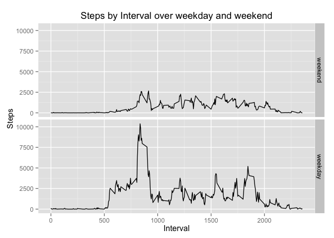

```r
library(ggplot2)
meanByInterval <- setNames(aggregate(activityDate$steps ~ activityDate$interval + activityDate$category, data = activityDate, FUN=sum, na.rm=TRUE), c("interval","category", "steps"))
ggplot(meanByInterval, aes(x=meanByInterval$interval, y=meanByInterval$steps)) +
        geom_line() +
        xlab("Interval") + ylab("Steps") +
        ggtitle(expression("Steps by Interval over weekday and weekend")) +
        facet_grid(category~ .)
```